# Final_Project

## Data Preprocessing

We saw in our initial analysis that we have a very wide range for population and income. This is detrimental to our analysis as values from a few countries will cause a heavy bias and potentially give us wrong observations/results. Hence, we will log transform the population and income variables. This will help us lower the range and weight of the outliers.

## Exploratory Data

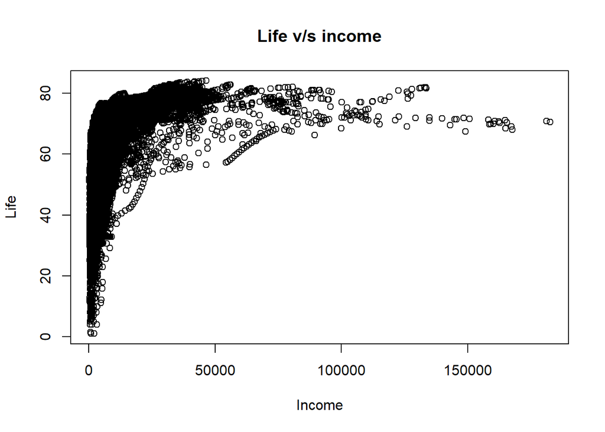

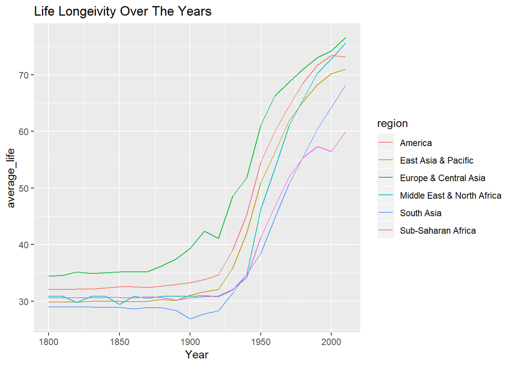

We see a definite correlation between life and income levels, we start seeing some oddities when we go part $50,000 where the increase in income has less effect on the increase in life expectancy.